# Bayenv Gene x Environment

M Fisher

7/7/2020

# Description

Analyze the results from Bayenv to explore gene x environment associations in the Korea P.cod RAD data.

In summary, there were 88 unique RAD loci that displayed ‘decisive’ evidence of an association with temperature-related environmental variables, including: maximum and mean sea surface temperature, mean and minimum temperature at maximum depth. I also included salinity by default, although I don’t think that this variable should be discussed in the manuscript.

For more summary information on the *Bayenv* results, including graphs and tables, skip down to the **Results** section. To understand the environmental variables and their values across sampling sites, look through the **Environmental Layers** section. Raw Bayes Factor values from *Bayenv* are explored in the **Bayenv Output** tab.

The script will use the function below to look at the spread of allele frequencies for a given locus, and decide whether a single population stands out as having a unique allele frequency, or whether the allele frequencies across the three populations are on a gradient. The comments describe the decision process for categorizing each locus.

```r
def_locus <- function(west_freq, south_freq, east_freq, limit){
  freqdat <- data.frame(west=west_freq,
                        south=south_freq,
                        east=east_freq) %>% mutate(we = abs(west-east),ws=abs(west-south),se=abs(south-east)) %>%
    # if the difference between south-west and south-east are greater than the difference between west-east, and
    #   west-east difference is > limit, south is the odd one out; if west-east difference is < limit, gradient
    # if the difference between east-west and south-west are greater than the difference between south-east, and
    #  south-east difference is > limit, west is the odd one out; if west-east difference i < limit, gradient
    mutate(def = ifelse(se > we & ws > we & we < limit, 'south',
                        ifelse(ws > se & we > se & se < limit, 'west','gradient')))
  return(freqdat$def)
}
```

# Environmental Layers

Environmental data is pulled from the [Bio-Oracle database](http://www.bio-oracle.org/). Ideally, we could use historical mean water temperature at spawning depth during the month of peak spawning, but this is not available from Bio-Oracle. Instead, sort through the temperature variables and pick out the ones that best highlight the thermal gradient created by the Tsushima Current through the Korea Strait.

The variables from Bio-Oracle are:

```
##  [1] "Var.BO_sstmax"            "Var.BO_sstmean"
##  [3] "Var.BO_sstrange"          "Var.BO2_tempmax_bdmean"
##  [5] "Var.BO2_tempmean_bdmean"  "Var.BO2_tempmin_bdmean"
##  [7] "Var.BO2_templtmax_bdmean" "Var.BO2_tempmax_bdmax"
##  [9] "Var.BO2_tempmean_bdmax"   "Var.BO2_tempmin_bdmax"
## [11] "Var.BO2_templtmax_bdmax"  "Var.BO_salinity"
```

## Sea Surface Temperature

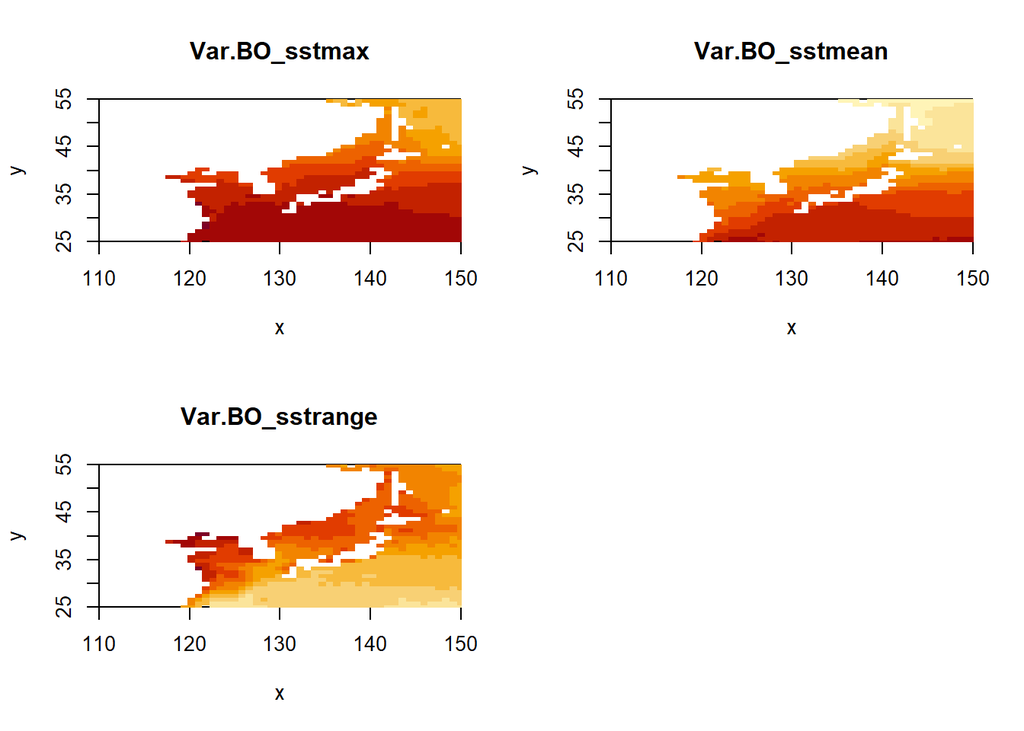

For the sampling sites:

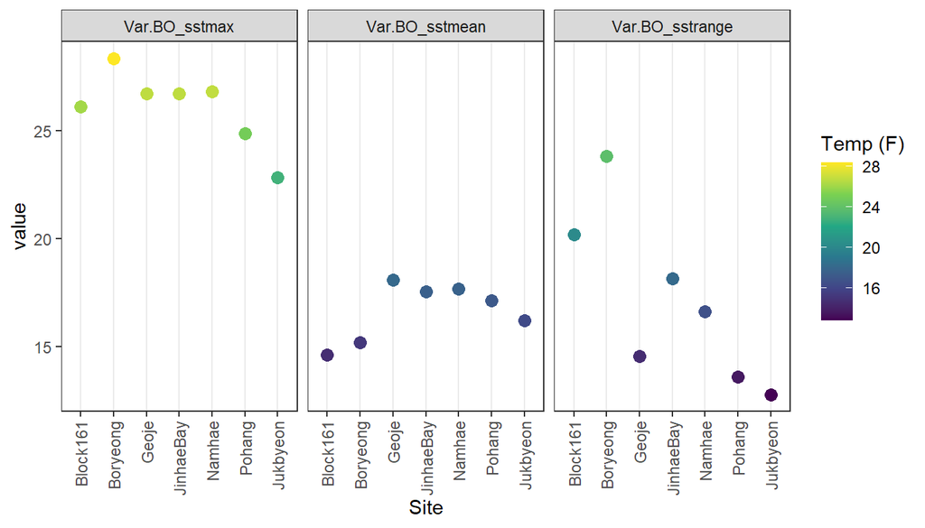

It’s interesting that temperature at Jukbyeon is not terribly different from Pohang - I’ll retain maximum and mean sea surface temperature (`Var.BO_sstmax` and `Var.BO_sstmean`).

## at Depth

Temperature at Mean Depth

For the sampling sites:

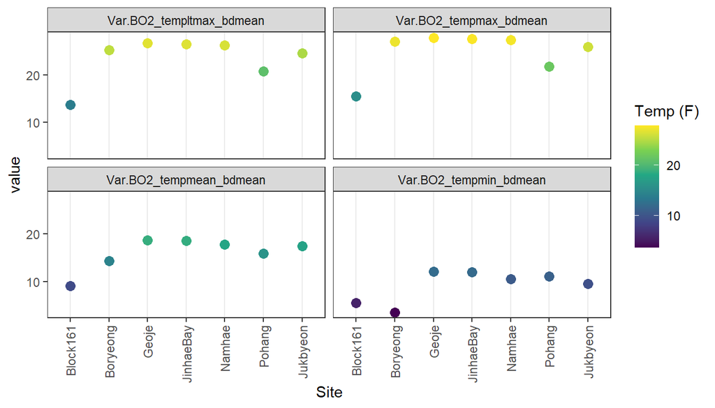

Temperature at Maximum Depth

For the sampling sites:

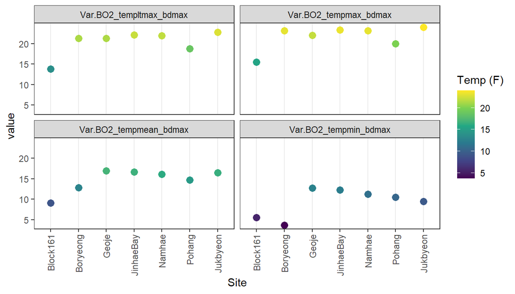

It looks like the site-specific differences in temperature at Max / Mean Depth are not terribly different. I’ll use maximum depth (since cod have benthic eggs). Mean and minimum temperatures appear to separate the Western from South / Eastern sites, although none of the variables separate the East Sea site at Jukbyeon from the southern coast sites.

## Salinity

For the sampling sites:

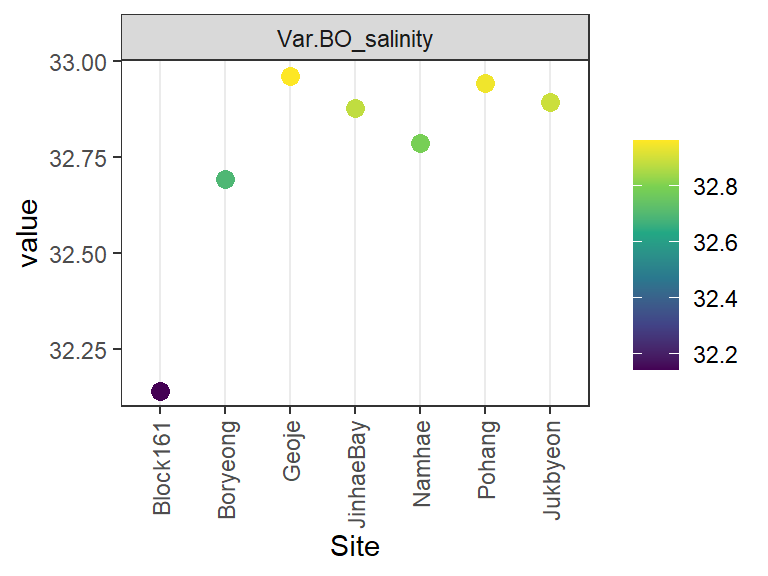

It makes sense that Block 161 is an outlier here, since it is much farther from shore than the other sites. I’ll check out the *Bayenv* output for salinity, but probably won’t use it in the paper.

# Bayenv Output

## Bayes Factors

Natalie took the raw *Bayenv* output matrix, renamed the loci for me, and re-arranged the data frame so that it was super easy to work with!

```
## 'data.frame':    5801 obs. of  13 variables:
##  $ LocusName            : int  10000 10004 10009 1001 10014 10015 10019 10020 10023 1003 ...
##  $ BO_sstmax            : num  0.205 0.137 0.158 0.224 0.123 ...
##  $ BO_sstmean           : num  0.246 0.205 0.287 0.305 0.475 ...
##  $ BO_sstrange          : num  0.191 0.146 0.199 0.255 0.13 ...
##  $ BO2_tempmax_bdmean   : num  0.157 0.127 0.21 0.234 2.982 ...
##  $ BO2_tempmean_bdmean  : num  0.167 0.149 0.301 0.248 2.096 ...
##  $ BO2_tempmin_bdmean   : num  0.225 0.207 0.243 0.29 0.212 ...
##  $ BO2_templtmax_bdmean.: num  0.156 0.129 0.216 0.245 2.885 ...
##  $ BO2_tempmax_bdmax    : num  0.163 0.121 0.2 0.27 2.592 ...
##  $ BO2_tempmean_bdmax   : num  0.178 0.146 0.298 0.245 1.818 ...
##  $ BO2_tempmin_bdmax    : num  0.271 0.19 0.246 0.271 0.265 ...
##  $ BO2_templtmax_bdmax  : num  0.156 0.123 0.225 0.25 2.816 ...
##  $ BO_salinity          : num  0.151 0.147 0.339 0.256 0.928 ...
```

The values associated with each locus x environmental layer are the Bayes factors. From Eleni’s notebook:

> The Bayes factor is a summary of the evidence provided by the data in favor of one scientific theory, represented by a statistical model, as opposed to another. According to Kass and Rafferty 1995 (“Bayes Factors”, Journal of the American Statistical Association, Vol. 90, No. 430 (Jun., 1995), pp. 773-795) Posterior odds = Bayes factor X Prior odds. So the Bayes factor is the ratio of the posterior odds of H1 to its prior odds, regardless of the value of the prior odds.

A higher Bayes factor suggests a stronger departure from $H_0$, the null hypothesis. Since the null hypothesis here is that there is no association between allele frequency and the environmental conditions, a higher Bayes factor suggests a stronger likelihood that there *is* an association between allele frequency and the environmental conditions (I’m using *likelihood* in the general sense, not pertaining the actual statistical likelihood).

How are the Bayes factors distributed for each variable of interest? Note that any locus with a Bayes factor above 100 will be plotted at the far right of the graph.

```
## Note: Using an external vector in selections is ambiguous.
## i Use `all_of(keep_vars)` instead of `keep_vars` to silence this message.
## i See <https://tidyselect.r-lib.org/reference/faq-external-vector.html>.
```

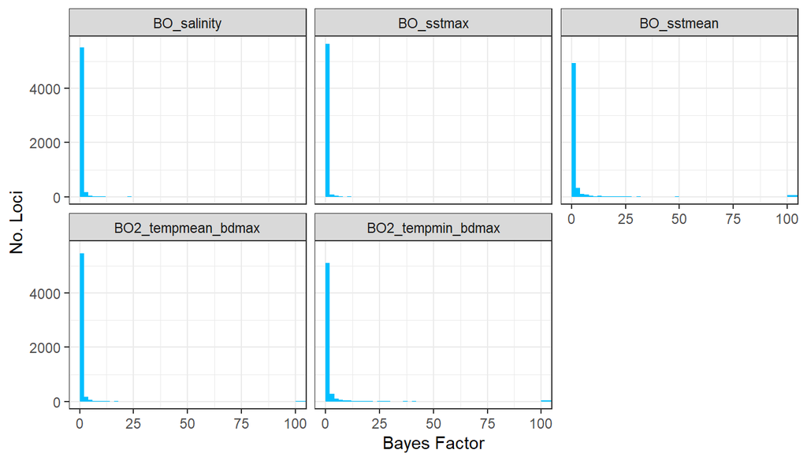

Cool! It looks like there are some loci with super high Bayes Factors associated with the mean / min temperature at max depth, and the mean SST.

```
## # A tibble: 5 x 2
##   variable           max_bayes_factor
##   <chr>                         <dbl>
## 1 BO_salinity                   1137.
## 2 BO_sstmax                      226.
## 3 BO_sstmean                   72201
## 4 BO2_tempmean_bdmax          108490
## 5 BO2_tempmin_bdmax            11549
```

## Log(BF)

From Eleni’s notebook:

> Jeffreys (1961, app. B) suggested interpreting the Bayes factor in half-units on the log (base 10) scale.

| $log_{10}(B_{10})$ | $B_{10}$ | Evidence against $H_0$ |
| --- | --- | --- |
| 0 to 1/2 | 1 to 3.2 | Negligable |
| 1/2 to 1 | 3.2 to 10 | Substantial |
| 1 to 2 | 10 to 100 | Strong |
| >2 | > 100 | Decisive |

So I’m going to take the $log_{10}$ of the Bayes factors, and then look at locus x environment associations that fall within the *Strong* (10-100) and the *Decisive* (>100) categories.

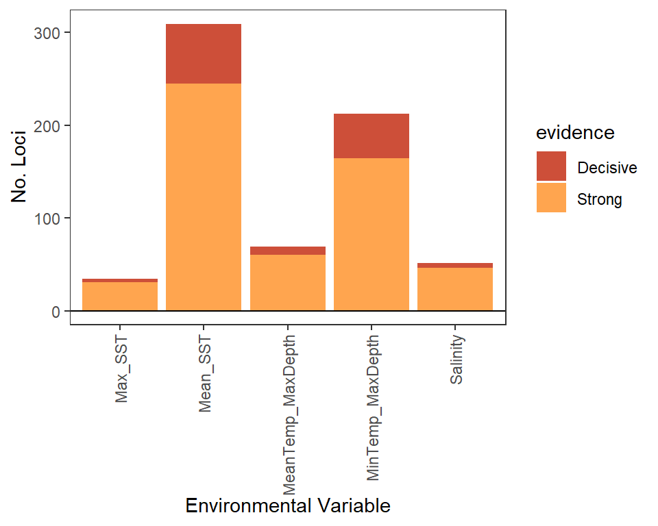

How many unique loci showed ‘decisive’ evidence of an association?

```
## [1] 88
```

```
## # A tibble: 5 x 2
##   variable          n_loci
##   <chr>              <int>
## 1 Max_SST                3
## 2 Mean_SST              64
## 3 MeanTemp_MaxDepth      9
## 4 MinTemp_MaxDepth      48
## 5 Salinity               5
```

Save the names of loci for which there is decisive evidence of an association between any of the temperature variables and the allele frequencies.

```r
bdat.out <- filter(bdat.high, variable != 'Salinity')
write.csv(bdat.out,here::here('results','bayenv_logBF_1plus_temp.csv'), row.names=FALSE)
```

# Results

Do the loci with decisive associations with the environmental variables show up as outliers? What are the allele frequencies associated with these loci in the West-South-East populations?

## All Allele Frequencies

I calculated allele frequencies for each locus with a ‘decisive’ association with an environmental variable using `adegenet` and `poppr` (R code output below). This includes 88 loci.

```
##
##  Converting data from a Genepop .gen file to a genind object...
##
##
## File description:  Korean Pacific cod filtered final genepop, stacks batch 8 MF 3/8/2018
##
## ...done.
```

```
## # A tibble: 6 x 6
##   LocusName variable         log_bf South  West   East
##       <dbl> <chr>             <dbl> <dbl> <dbl>  <dbl>
## 1     10123 Mean_SST           2.33 0.566 0.222 0.212
## 2     10203 Mean_SST           3.66 0.253 0.728 0.714
## 3     10203 MinTemp_MaxDepth   2.23 0.253 0.728 0.714
## 4     10376 Mean_SST           2.93 0.352 0.110 0.0192
## 5     10376 MinTemp_MaxDepth   2.11 0.352 0.110 0.0192
## 6     10376 Salinity           2.00 0.352 0.110 0.0192
```

**Figure** Compare allele frequencies between the Southern (x axis), Western (y axis), and Eastern (point color) populations for all loci with ‘decisive’ environmental associations.

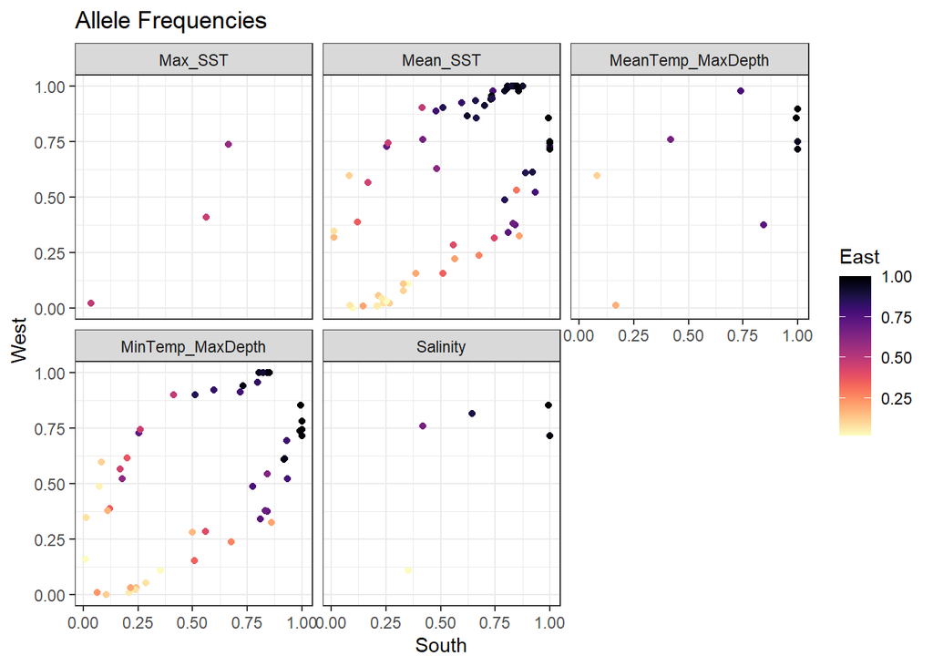

### SST

**Figure** Allele frequencies (standardized by total) of each locus for the 3 populations (South, West, East) for all loci with decisive associations with the two Sea Surface Temperature environmental variables (mean and maximum).

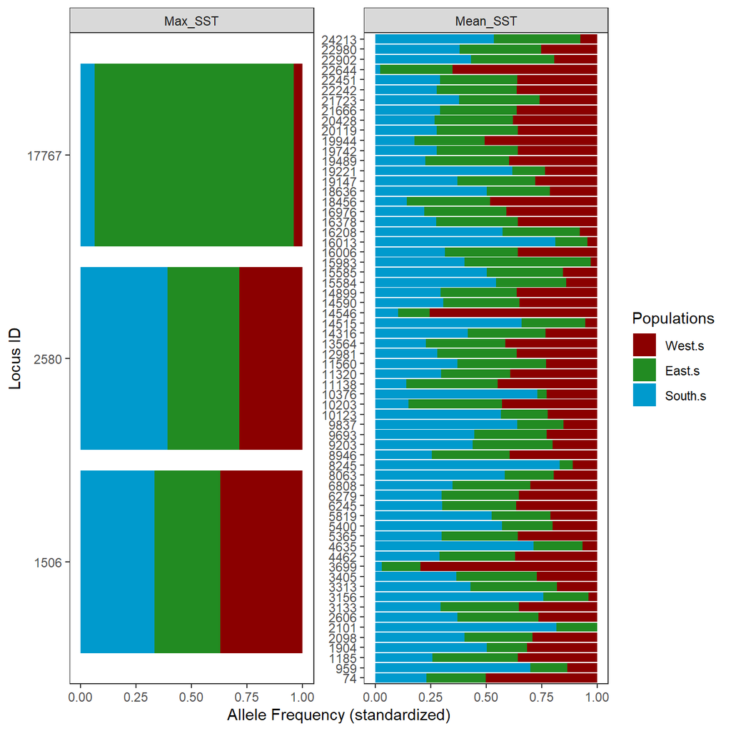

### Max Depth Temp

**Figure** Allele frequencies (standardized by total) of each locus for the 3 populations (South, West, East) for all loci with decisive associations with the two Temperature at Maximum Depth environmental variables (mean and minimum).

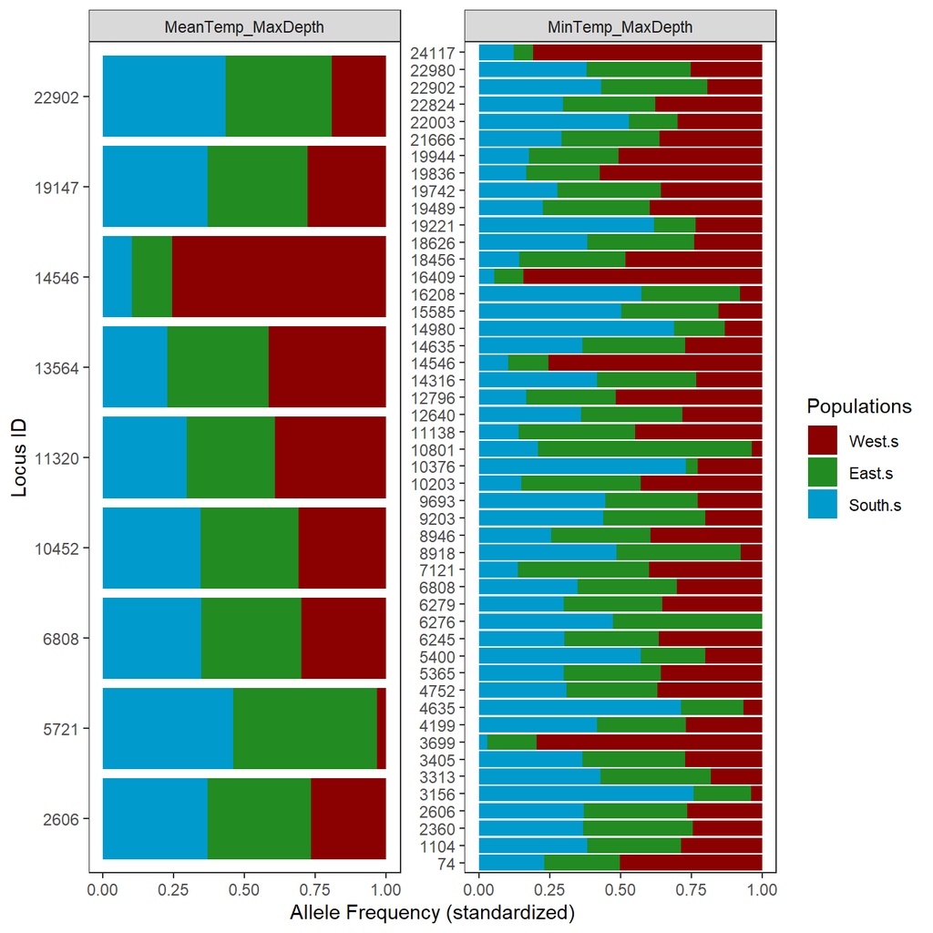

## Outlier Loci

These are the outlier loci which were identified by both Bayescan and OutFlank

```
##  [1] 10203  3699  8290    74 16976 18636   453  2705 15585 16378 22902  3313
```

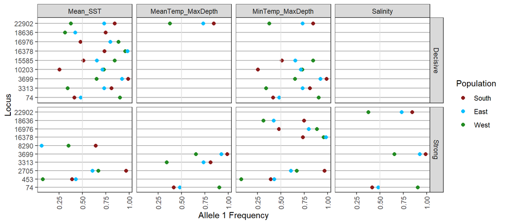

**Table** Outlier loci identified in both Bayescan and Outlank which had either strong (1-2) or decisive (> 2) associations with environmental variables for which *the allele frequency of the Southern population was distinct from that of the Western / Eastern population*. Allele frequencies are provided for each population (West, South, East columns), as well as the log(Bayes Factor) for each environmental variable association (Mean SST, Minimum Temperature at maximum depth). Note that locus 10203 aligned to a reproduction-associated protein-coding region in the Atlantic cod genome.

```
## # A tibble: 5 x 7
##   locus_id gene_id        West South  East Mean_SST MinTemp_MaxDepth
##      <int> <fct>         <dbl> <dbl> <dbl>    <dbl>            <dbl>
## 1    10203 GAMO_00009696 0.728 0.253 0.714     3.66             2.23
## 2    16976 GAMO_00019717 0.886 0.478 0.796     2.59             1.46
## 3    18636 GAMO_00066962 0.315 0.747 0.423     3.18             1.74
## 4     2705 GAMO_00024607 0.67  0.965 0.607     1.81             1.10
## 5    16378 GAMO_00009513 0.956 0.734 0.982     2.41             1.47
```

**Table** Outlier loci identified in both Bayescan and Outlank which had either strong (1-2) or decisive (> 2) associations with environmental variables for which *the allele frequency of the Western population (Yellow Sea) was distinct from that of the Southern / Eastern population*. Allele frequencies are provided for each population (West, South, East columns), as well as the log(Bayes Factor) for each environmental variable association (Mean SST, Minimum Temperature at maximum depth). Note that locus 3699 aligned to a reproduction-associated protein-coding region in the Atlantic cod genome.

```
## # A tibble: 5 x 9
##   locus_id gene_id  West South  East Mean_SST MeanTemp_MaxDep~ MinTemp_MaxDepth
##      <int> <fct>   <dbl> <dbl> <dbl>    <dbl>            <dbl>            <dbl>
## 1     3699 GAMO_0~ 0.652 0.987 0.923     2.97             1.44             2.40
## 2       74 GAMO_0~ 0.902 0.415 0.481     3.81             1.77             2.60
## 3      453 GAMO_0~ 0.076 0.39  0.429     1.95            NA                1.57
## 4    22902 GAMO_0~ 0.375 0.843 0.731     3.58             2.32             2.14
## 5     3313 GAMO_0~ 0.341 0.809 0.732     2.99             1.08             2.57
## # ... with 1 more variable: Salinity <dbl>
```

Write out the combined data.

```r
comp.out <- pivot_wider(compdat, names_from="Population",values_from="A1_Freq")
write.csv(bdat.out,here::here('results','outliers_bayenv_logBF_1plus_A1Freq.csv'), row.names=FALSE)
```